# Rennacker_HW_3

Author

Travis Rennacker

Libraries

```r
#|output: false

library(here)
library(janitor)
library(tidyverse)
library(pracma)
```

```r
MAC_M <- function(a){
  m=a*4
  return(m)
}

MAC_K <- function(a){
  m=a*4.5
  return(m)
}

MAC_A <- function(a){
  m=a*3
  return(m)
}

MAC_V <- function(a){
  m=a*2
  return(m)
}
```

Prices are in $/Acre Foot and quantities are in Acre Feet (AF). ● Suppose groundwater abatement costs for each firm have been estimated for you by a team of agroecologists and the marginal abatement cost (MAC) curves are as follows: o Kern: MAC = 4.5A (where A = abatement) o Mojave: MAC = 4A o Antelope: MAC = 3A o Ventura: MAC = 2A

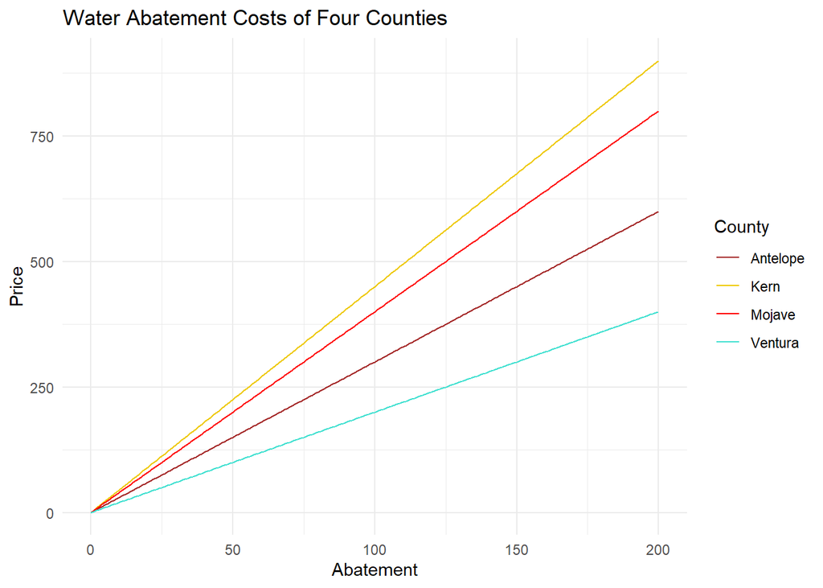

```r
s_values <- seq(0, 200, by = 1)
m_values <- sapply(s_values, MAC_M)
k_values <- sapply(s_values, MAC_K)
a_values <- sapply(s_values, MAC_A)
v_values <- sapply(s_values, MAC_V)

Mdata <- data.frame(a = s_values, y = m_values, type = "Mojave")
Kdata <- data.frame(a = s_values, y = k_values, type = "Kern")
Adata <- data.frame(a = s_values, y = a_values, type = "Antelope")
Vdata <- data.frame(a = s_values, y = v_values, type = "Ventura")

# Combine all the data frames into one
all_data <- rbind(Mdata, Kdata, Adata, Vdata)

# Plot using ggplot2
ggplot(all_data, aes(x = a, y = y, color = type)) +
  geom_line() +
  labs(title = "Water Abatement Costs of Four Counties",
       x = "Abatement",
       y = "Price", color="County") +
  theme_minimal() +
  scale_color_manual(values = c("Mojave" = "red", "Kern" = "gold2", "Antelope" = "brown", "Ventura" = "turquoise"))
```

# Question 1 Response:

While there is no limit on the ability of each county to abate groundwater usage, there is an increased cost associated respective of location. It would be most cost effective for Ventura County to utilize abatement methods.

# Question 2 Response:

# 2 a.

Each District would Abate 50 units.

Amount of Abatement

```r
MAC_K(50)
```

```
[1] 225
```

```r
MAC_M(50)
```

```
[1] 200
```

```r
MAC_A(50)
```

```
[1] 150
```

```r
MAC_V(50)
```

```
[1] 100
```

```r
abatement_strict <- data.frame(
  price = c(100, 150, 200, 225),
  county = c("Ventura", "Antelope", "Mojave", "Kern"))

abatement_strict
```

```
  price   county
1   100  Ventura
2   150 Antelope
3   200   Mojave
4   225     Kern
```

```r
bh <- function(b,h){
  a=(b*h)/2
  return(a)
}

bh(50,100) #ventura
```

```
[1] 2500
```

```r
bh(50,150) #antelope
```

```
[1] 3750
```

```r
bh(50,200) #mojave
```

```
[1] 5000
```

```r
bh(50,225) #kern
```

```
[1] 5625
```

```r
abatement_strict |> mutate(total_cost = c(2500, 3750, 5000, 5625))
```

```
  price   county total_cost
1   100  Ventura       2500
2   150 Antelope       3750
3   200   Mojave       5000
4   225     Kern       5625
```

```r
#2500 + 3750 +5000 + 5625 #Total cost for all firms at 200 AF of abatement
```

Total Cost for all counties: $16875

# 2 b.

MAC_K = 4.5a : A_K = p/4.5 MAC_M = 4a : A_M = p/4 MAC_A = 3a : A_A = p/3 MAC_V = 2a : A_V = p/2

A_K + A_M + A_A + A_V = Aggregate Abatement

Market is set at 200AF of abatement by government

Aggregate Abatement = 200AF

```r
#Function of agg cost
f_AA <- function(x) {
  200 - (x / 4.5 + x / 4 + x / 3 + x / 2)
}

#set interval for root
result <- uniroot(f_AA, c(0, 1000))

#Show results
result$root
```

```
[1] 153.1915
```

# Equilibrium Market Price with cap and trade : $153.19

```r
A_K  <- function(p) {
  a = p/4.5
  return(a)
}


A_M <- function(p) {
  a = p/4
  return(a)
}

A_A <- function(p) {
 a = p/3
 return(a)
}

A_V <- function(p) {
  a = p/2
  return(a)
}

bh <- function(b,h){
  a=(b*h)/2
  return(a)
}


bh(A_K(153.1915) , 153.19)
```

```
[1] 2607.49
```

```r
bh(A_M(153.1915) , 153.19)
```

```
[1] 2933.426
```

```r
bh(A_A(153.1915) , 153.19)
```

```
[1] 3911.234
```

```r
bh(A_V(153.1915) , 153.19)
```

```
[1] 5866.851
```

```r
dfa <- data.frame(abatement = c(A_K(153.1915),A_M(153.1915),A_A(153.1915),A_V(153.1915)), county= c("Kern", "Mojave", "Antelope", "Ventura"), "total abatement cost per county" = c(2607.49, 2933.426, 3911.234, 5866.851))

dfa
```

```
  abatement   county total.abatement.cost.per.county
1  34.04256     Kern                        2607.490
2  38.29787   Mojave                        2933.426
3  51.06383 Antelope                        3911.234
4  76.59575  Ventura                        5866.851
```

```r
(A_K(153.1915) * 153.19)/2 + (A_M(153.1915) * 153.19)/2 + (A_A(153.1915) * 153.19)/2 + (A_V(153.1915) * 153.19)/2
```

```
[1] 15319
```

```r
16875 - 15319
```

```
[1] 1556
```

The above table displays how much abatement each county would revert to in a cap and trade scenerio.

Total Abatement Cost : $ 15319

Total gains under cap and trade : 16875 - 15319 = **$1556**

# 2 c.

To decrease the amount of water used by 200AF, a tax should be set at $ 153.1915.

```r
dfa
```

```
  abatement   county total.abatement.cost.per.county
1  34.04256     Kern                        2607.490
2  38.29787   Mojave                        2933.426
3  51.06383 Antelope                        3911.234
4  76.59575  Ventura                        5866.851
```

```r
sum(dfa$abatement, na.rm = TRUE)
```

```
[1] 200
```

Each district would abate the above amount. Total cost is also listed above.

Total Abatement Across Districts: 200 AF

Total cost of abatement for each district to comply listed in the above table

```r
#THIS IS WRONG THEY ALL DONT ABATE 100 They each used 100...
f_AMV <- function(p) {
  100 - ( p / 4 + p / 3 + p / 2)
}

#set interval for root
result <- uniroot(f_AMV, c(0, 1000))

#Show results
result$root
```

```
[1] 92.30769
```

```r
A_M(92.307)
```

```
[1] 23.07675
```

```r
A_A(92.307)
```

```
[1] 30.769
```

```r
A_V(92.307)
```

```
[1] 46.1535
```

```r
MAC_K(200)
```

```
[1] 900
```

```r
# 100 AF for
# (100-abatement_per_county)*tax
#
kern  <- (200 - 34.04256)*153.1915  #Kern
 mojave <- (100 - 38.29787)*153.1915    #Mojave
   antelope <- (100 - 51.06383)*153.1915    #Antelope
    ventura <-(100 - 76.59575)*153.1915 #Ventura

tax_revenue <- data.frame(county= c("Kern", "Mojave", "Antelope", "Ventura"), "tax revenue" = c(kern, mojave, antelope, ventura))

tax_revenue
```

```
    county tax.revenue
1     Kern   25423.269
2   Mojave    9452.242
3 Antelope    7496.605
4  Ventura    3585.332
```

3. Tax on groundwater use. Suppose instead a single tax is implemented on all water use such that water use is reduced by 200AF summed across the four districts. What is that tax level? How much would each district abate? What is total abatement across districts? What is the total cost of abatement for each district to comply? How much tax revenue is generated if initial water use is 100 AF for Ventura, Antelope, and Mojave and 200 for Kern?

I’m confused bewteen the amounts, and terms. The goal of the tax is to abate… so if their water use was 100AF and through the tax we reduce water consumption by 38.29787 for mojave, do they then consume 100-38.30? 61.70 AF water consumption? so then is tax revenue be the area of abatemnent? ie from 61-100 at 153.19$ or (38.30*153)/2? …